# POLI 110: Confounding

November 25, 2025

## Correlation to Causation

## Solutions to Confounding

\(1\). Conditioning:

- What is it?
- How does it work?
- Assumptions?

\(2\). “Design Based” approach

- what is it?
- how does it work?

## Recap

## Solutions to Confounding

Must ask…

- What **comparisons** between cases does it involve?
  - can you **recognize** this solution when it is described to you?
  - can you **describe** how to use this solution to test a particular causal claim?
- What **assumptions** are required for it to work?
- *How* does it “solve” confounding?
- What **trade offs** do we make?

### Experiment:

Does exposure to mass-shootings increase support for laws restricting access to guns?

**What would an experiment look like?**:

**What confounding is removed?**:

**What is assumed?**:

**Internal vs External validity?**

### Example:

Does exposure to mass-shootings increase support for laws restricting access to guns? ([McGinty et al 2013](https://psychiatryonline.org/doi/10.1176/appi.ajp.2013.13010014))

**What would an experiment look like?**: Recruit people into a survey. Randomly assign respondents to read/not read a news story about a mass shooting

**What confounding is removed?**: All confounding variables

**What is assumed?**: Random assignment, changing nothing other than \(X\)

**Internal vs External validity?**

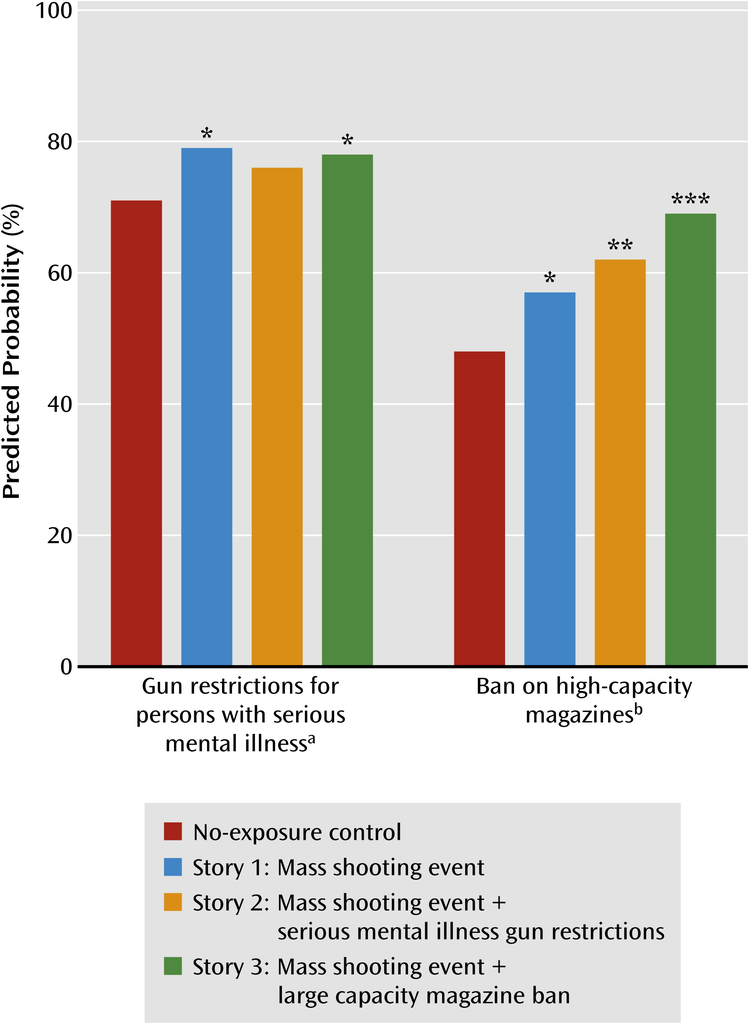

| Solution | How Confounding Solved | Which Confounding Removed | Assumes | Internal Validity | External Validity |
| --- | --- | --- | --- | --- | --- |
| Experiment | Randomization Breaks \(W \rightarrow X\) link | **All** confounding variables | \(X\) is random; Change only \(X\) | High | Low |

## Conditioning

Did Trump rallies cause hate crimes?

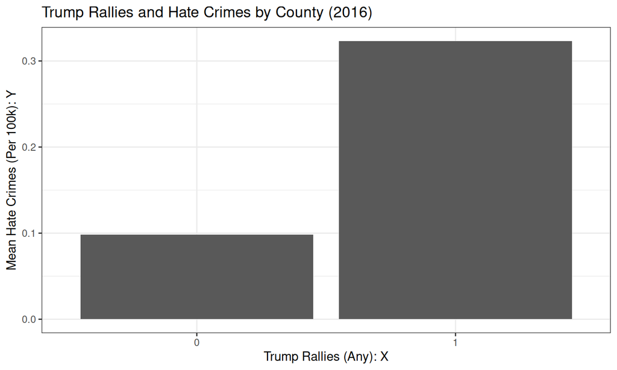

data from [Feinberg, Branton, and Martinez-Ebers](https://lmas.unt.edu/sites/lmas.unt.edu/files/lmas/Hate%20Incidents%20Spike_0.pdf)

Possible confounders imagined by [Feinberg, Branton, and Martinez-Ebers](https://lmas.unt.edu/sites/lmas.unt.edu/files/lmas/Hate%20Incidents%20Spike_0.pdf)

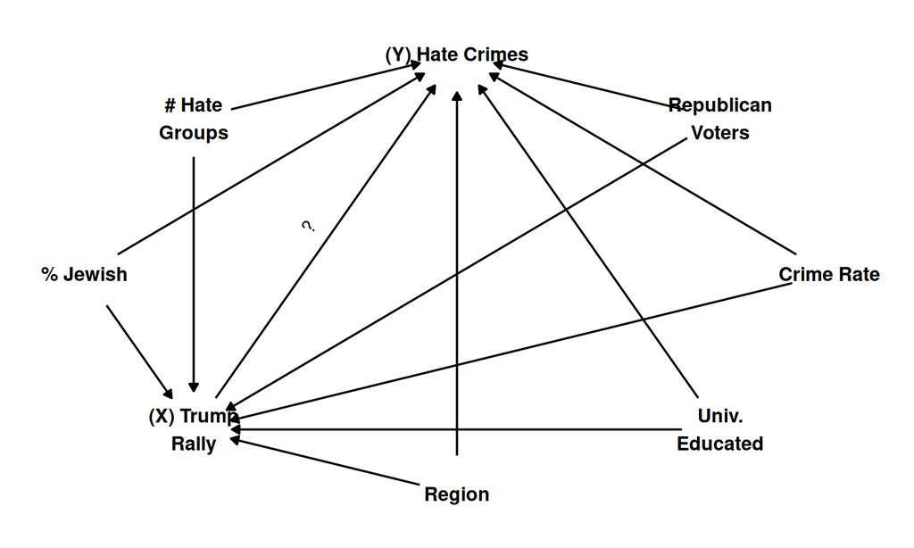

## Conditioning

### **conditioning**

when we observe \(X\) and \(Y\) for multiple cases, we examine the correlation of \(X\) and \(Y\) *within* groups of cases that are **the same** on confounding variables \(W, etc. \ldots\)

How does conditioning solve the problem?

- Cases compared have **same values** on confounding variable(s) \(W\)
- In these groups, \(W\) cannot affect \(X\) or \(Y\) (because \(W\) is not moving, it can’t move \(X\) or \(Y\))
- “Backdoor path” from \(X\) to \(Y\) is “blocked”

How does conditioning work?

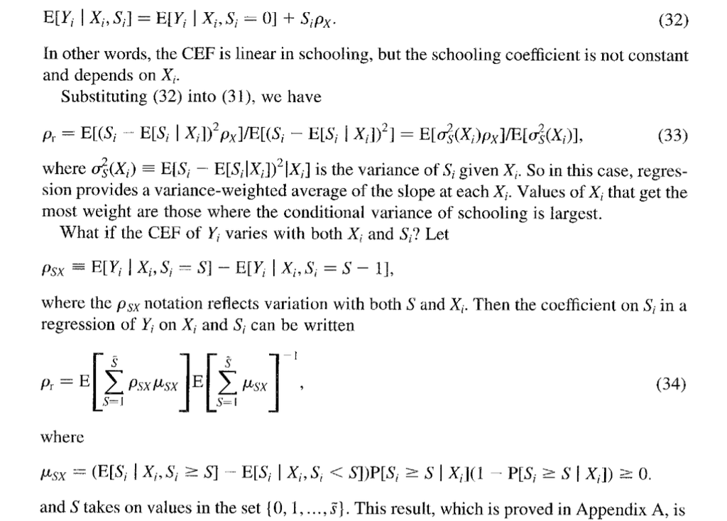

Just kidding!

[figure not shown]

## Example: Conditioning

[Feinberg, Branton, and Martinez-Ebers](https://lmas.unt.edu/sites/lmas.unt.edu/files/lmas/Hate%20Incidents%20Spike_0.pdf) compare hate crimes in counties with and without Trump rallies, but condition on (hold constant):

- percent Jewish
- number of hate groups
- crime rate
- 2012 Republican vote share
- percent university educated
- region

## Example: Conditioning

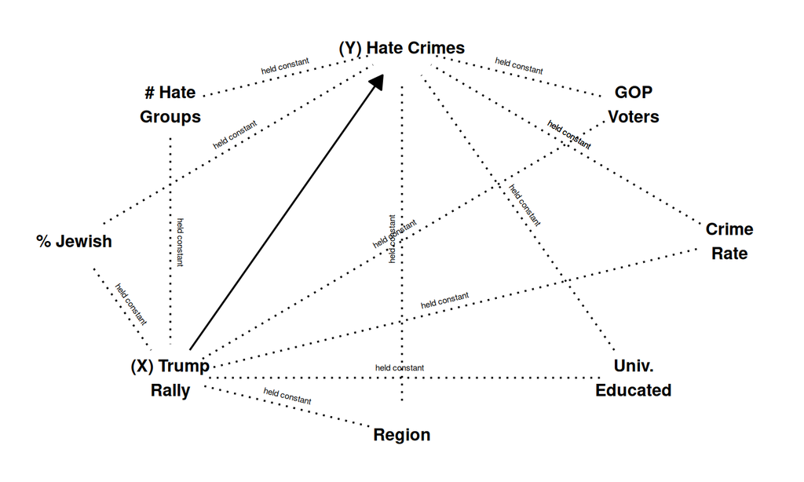

## Example: Conditioning

| County | HC(Yes) Y | HC(No) Y | Rally (X) | Jewish % | Hate Groups | Crime Rate | Rep. % | Univ. % | Region |
| --- | --- | --- | --- | --- | --- | --- | --- | --- | --- |
| a | \(More\) | \(\color{red}{Fewer}\) | Yes | 2 | 3 | 15 | 53 | 38 | South |
|  | \(\Downarrow\) | \(\Uparrow\) |  |  |  |  |  |  |  |
| b | \(\color{red}{More}\) | \(Fewer\) | No | 2 | 3 | 15 | 53 | 38 | South |

## Example: Conditioning

[Feinberg, Branton, and Martinez-Ebers](https://lmas.unt.edu/sites/lmas.unt.edu/files/lmas/Hate%20Incidents%20Spike_0.pdf) find that, even after conditioning, Trump rallies increase the risk of hate crimes by 200%!

- Lots of news headlines [like this](https://www.vox.com/2019/3/24/18279807/trump-hate-crimes-study-white-nationalism)

## Example: Conditioning

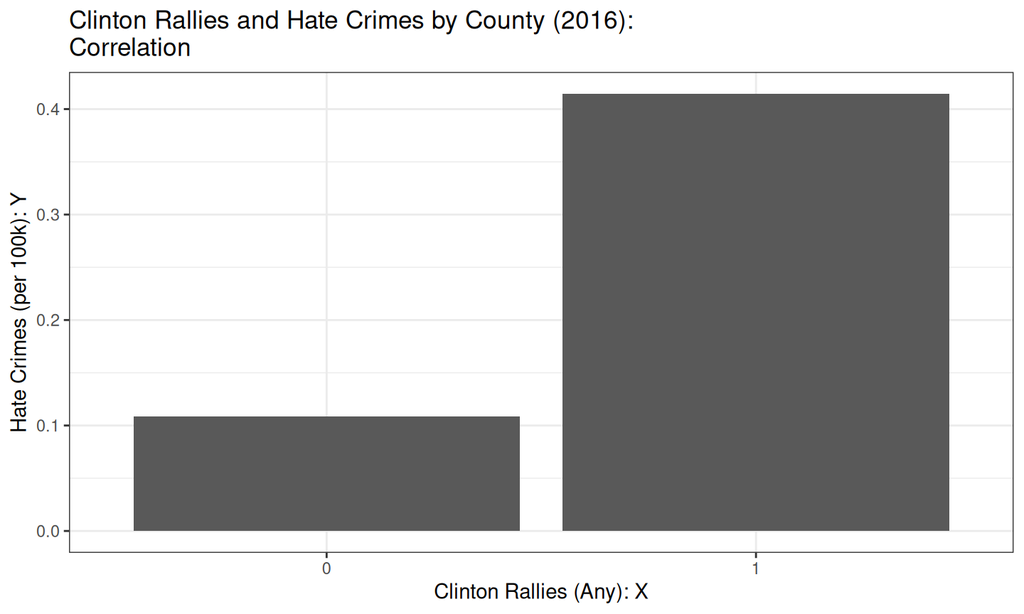

## Example: Conditioning

[Economics PhD Candidates](https://github.com/lilleymatthew/Trump_Rallies_Replication_Materials/blob/master/Trump_Rallies_and_Hate_Crimes.pdf) show that **conditioning on the same variables**…

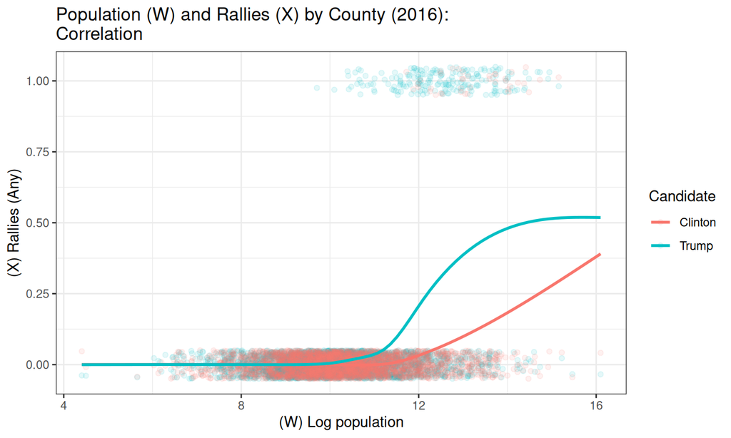

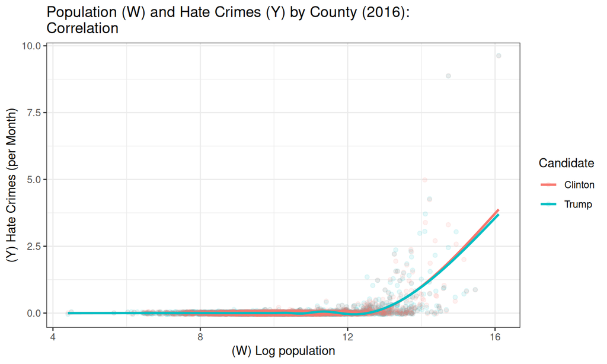

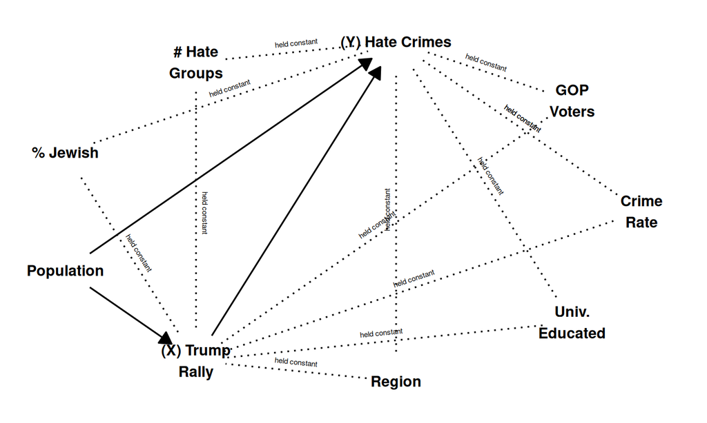

| County | HC(Yes) Y | HC(No) Y | Rally (X) | Jewish % | Hate Groups | Crime Rate | Rep. % | Univ. % | Region | Pop. |
| --- | --- | --- | --- | --- | --- | --- | --- | --- | --- | --- |
| a | \(More\) | \(\color{red}{More}\) | Yes | 2 | 3 | 15 | 53 | 38 | South | **High** |
|  | \(\not\Downarrow\) | \(\not\Uparrow\) |  |  |  |  |  |  |  |  |
| b | \(\color{red}{Fewer}\) | \(Fewer\) | No | 2 | 3 | 15 | 53 | 38 | South | **Low** |

We would be wrong to use observed hate crimes in county \(b\) (without a rally) to substitute in for counterfactual hate crimes in county \(a\) (without a rally).

Population differences \(\to\) difference in hate crimes regardless of rally.

After also conditioning on population (a confounder): no correlation.

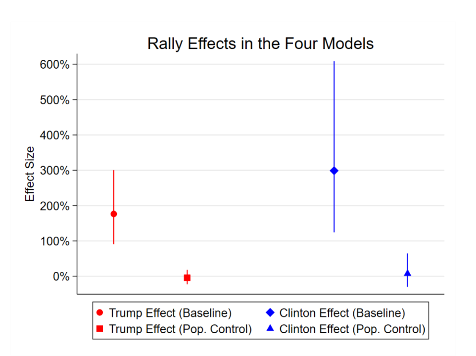

| Solution | How Confounding Solved | Which Confounding Removed | Assumes | Internal Validity | External Validity |
| --- | --- | --- | --- | --- | --- |
| Experiment | Randomization Breaks \(W \rightarrow X\) link | **All** confounding variables | \(X\) is random; Change only \(X\) | High | Low |
| Conditioning | Hold confounders constant | ? | ? | ? | High |

## Assumptions

## Conditioning Assumptions

In order to use conditioning to infer \(X\) causes \(Y\) if \(X,Y\) correlated …

### **Must Assume**

1. There are **no other confounding variables** (that you have not conditioned on)
   - i.e. you have conditioned on ALL confounding variables (backdoor paths)
   - sometimes called “ignorability assumption”: you assume you can “ignore” other variables without confounding

**How can we tell whether this assumption is correct?**

DISCUSS WITH YOUR NEIGHBORS

## Conditioning Assumptions

1. Assume there are **no other confounding variables** (that you have not conditioned on)
- this can never be proven to be true: a “strong” assumption
- we can’t know whether all confounders are blocked because we don’t know true causal graph
- compare this against the assumption of randomization in experiments

## Example

In wake of mass shootings, we might ask:

**Do mass shooting events cause people to become more supportive of stricter gun control policies?**

## Example

[figure not shown]

## Example

[Newman and Hartman (2017)](https://www.cambridge.org/core/journals/british-journal-of-political-science/article/mass-shootings-and-public-support-for-gun-control/8F38356AF4DB22B8B7DF28052234FA09) examine whether exposure to mass shootings cause an increase in support for stricter gun control

- \(Y\) large survey (CCES) asks: “In general, do you feel that laws covering the sale of firearms should be made more strict, less strict, or kept as they are?”
- \(X\) “distance to nearest mass shooting in recent years”
- **What might be possible confounding variables?**

## Example

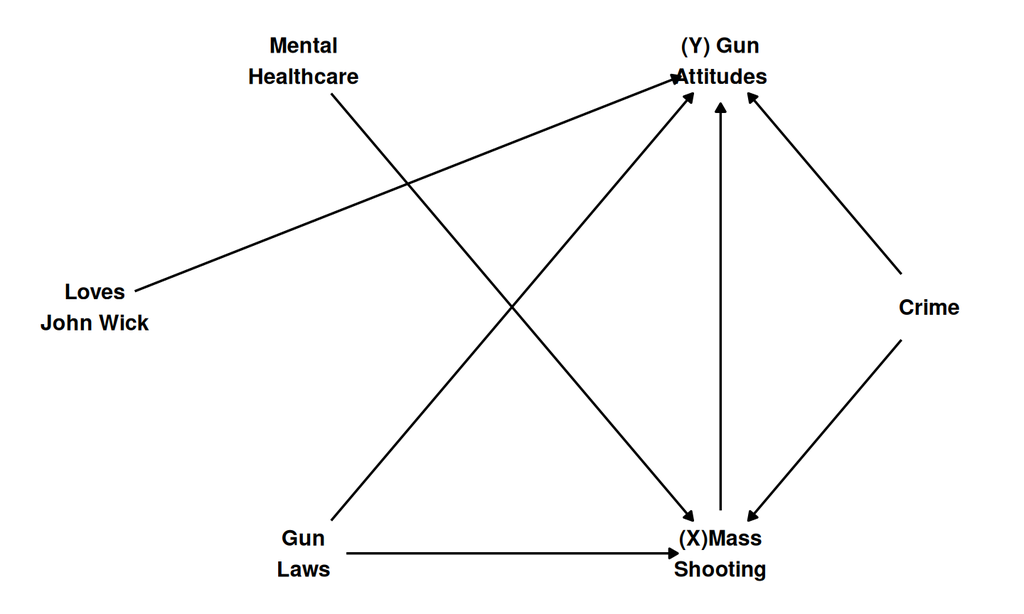

Which variables do we NEED to condition on? Which variables do we NOT NEED to condition on?

## Assumptions

**Must Assume**

1. There are **no other confounding variables** (that you have not conditioned on)
- i.e. you have conditioned on ALL confounding variables
- this can never be proven to be true: a “strong” assumption

But…

- don’t need to condition on **ALL** variables that might affect \(X\) or affect \(Y\): only confounders.

## Example

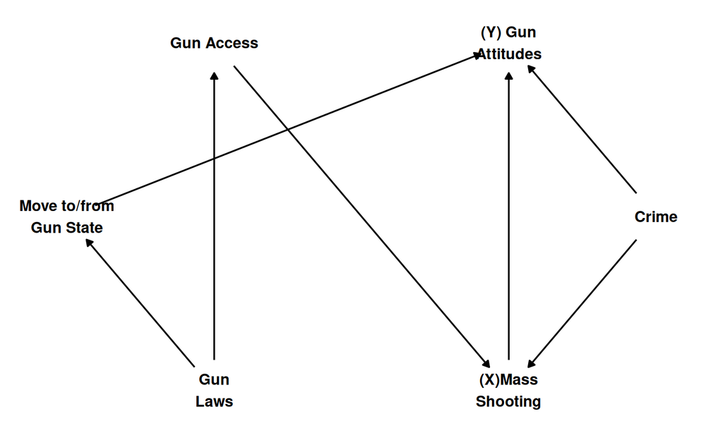

Which variables do we NEED to condition on? Which variables do we NOT NEED to condition on?

## Assumptions

**Must Assume**

1. There are **no other confounding variables** (that you have not conditioned on)
- i.e. you have conditioned on ALL confounding variables
- this can never be proven to be true: a “strong” assumption

But…

- don’t need to condition on **ALL** variables that might affect \(X\) or affect \(Y\): only confounders.
- don’t need to condition on **ALL** variables on a backdoor path. Just one variable per backdoor path is needed.

## Example

[Newman and Hartman (2017)](https://www.cambridge.org/core/journals/british-journal-of-political-science/article/mass-shootings-and-public-support-for-gun-control/8F38356AF4DB22B8B7DF28052234FA09):

Compare proximity to mass shooting and gun control attitudes, conditioning on (holding constant:

- **community level** factors: income, education, partisanship, racial composition, murder, firearms stores, population density, population
- **individual level** factors: education, income, age, gender, race, property ownership, having children, in military, military family, partisanship, ideology, religiosity, region of birth
- Are there any potentially **really important** confounders that might not be included?

[figure not shown]

Proximity to mass shootings increases support for stricter gun laws… **assuming no other confounders**

## Assumptions

**Must Assume**

1. There are **no other confounding variables** (that you have not conditioned on)

But…

- don’t need to condition on **ALL** variables that might affect \(X\) or affect \(Y\): only confounders.
- don’t need to condition on **ALL** variables on a backdoor path. Just one variable per backdoor path is needed.
- we **can** give reasons/arguments for why any remaining confounding is likely small OR biased against the correlation (*small* bias may not be enough to change our conclusions, or bias is **against** our conclusions)

| Solution | How Confounding Solved | Which Confounding Removed | Assumes | Internal Validity | External Validity |
| --- | --- | --- | --- | --- | --- |
| Experiment | Randomization Breaks \(W \rightarrow X\) link | **All** confounding variables | \(X\) is random; Change only \(X\) | High | Low |
| Conditioning | Hold confounders constant | Only variables conditioned on | Condition on all confounders | Low | High |

## Conditioning Assumptions

In order to infer \(X\) causes \(Y\) if \(X,Y\) correlated after conditioning

### **Must Assume**

2. **Variables used to condition** relationship between \(X\) and \(Y\) are **measured without error**.
- even **random measurement error** in confounding variables leads conditioning to not remove bias.
- Why? You are no longer comparing like-with-like.

## Conditioning Assumptions

Imagine we want to condition on gun ownership, when examining correlation of mass shootings and gun attitudes.

What if we measure **gun ownership** with random measurement error?

Let’s see what happens… BOARD

## Conditioning Assumptions

In order to infer \(X\) causes \(Y\) if \(X,Y\) correlated after conditioning

### **Must Assume**

3. We can **find** cases that are **the same** on confounding variables \(W\) and different in \(X\).

## Example:

Let’s say we want to examine the effect of laws restricting gun ownership on gun violence across **countries**:

What are some factors that might affect strictness of gun regulation and gun violence?

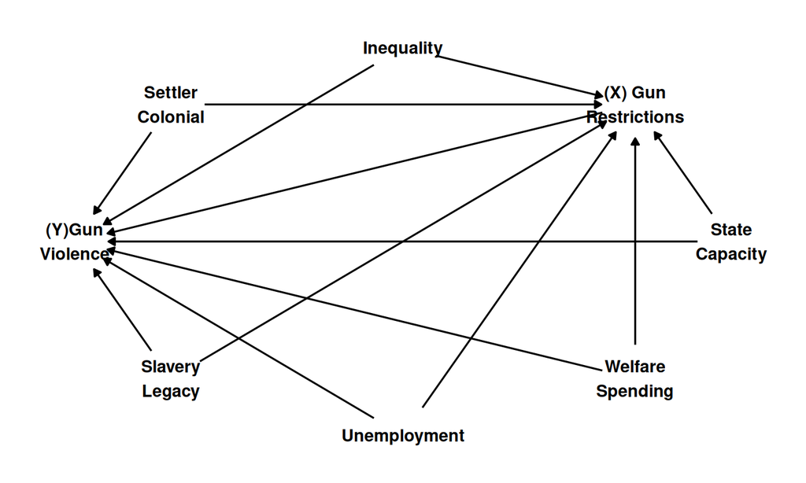

Is there, e.g., country that is similar to the US on all confounders?

## Conditioning: Limitations

In order to infer \(X\) causes \(Y\) if \(X,Y\) correlated after conditioning

### **Must Assume**

3. There are cases that are **the same** on confounding variables \(W\) and different in \(X\).
- as we want to condition on more and more variables…
- less and less likely we find cases that exactly match
- so, cannot condition on all confounding variables

| Solution | How Confounding Solved | Which Confounding Removed | Assumes | Internal Validity | External Validity |
| --- | --- | --- | --- | --- | --- |
| Experiment | Randomization Breaks \(W \rightarrow X\) link | **All** confounding variables | \(X\) is random; Change only \(X\) | High | Low |
| Conditioning | Hold confounders constant | Only variables conditioned on | Condition on all confounders; Low measurement error; Have similar cases | Low | High |

## Beyond Conditioning

## Limits of Conditioning:

### **Did Trump rallies *increase* hate crimes?**

1. If we know confounding variables, can we find cases *with* and *without* rallies that are **the same on *many* confounding variables**?
2. If we don’t know or can’t measure confounding variables, may **still be differences** between places with and without rallies that produce confounding.
- Is there a **better comparison** we can make?

## Before and After

We can make Before and After comparisons: What is it?

**before and after**: examine the change in \(Y\) in a single case (or group of cases) where \(X\) changes over time (from before to after)

## Example: Before and After

Taking the same data from [Feinberg, Branton, and Martinez-Ebers](https://lmas.unt.edu/sites/lmas.unt.edu/files/lmas/Hate%20Incidents%20Spike_0.pdf)…

- we focus **only** on counties that **ever had** a Trump (Clinton) rally
- compare the month **after** the rally \((X = \text{Rally})\) to the month **before** the rally \((X = \text{No Rally})\)

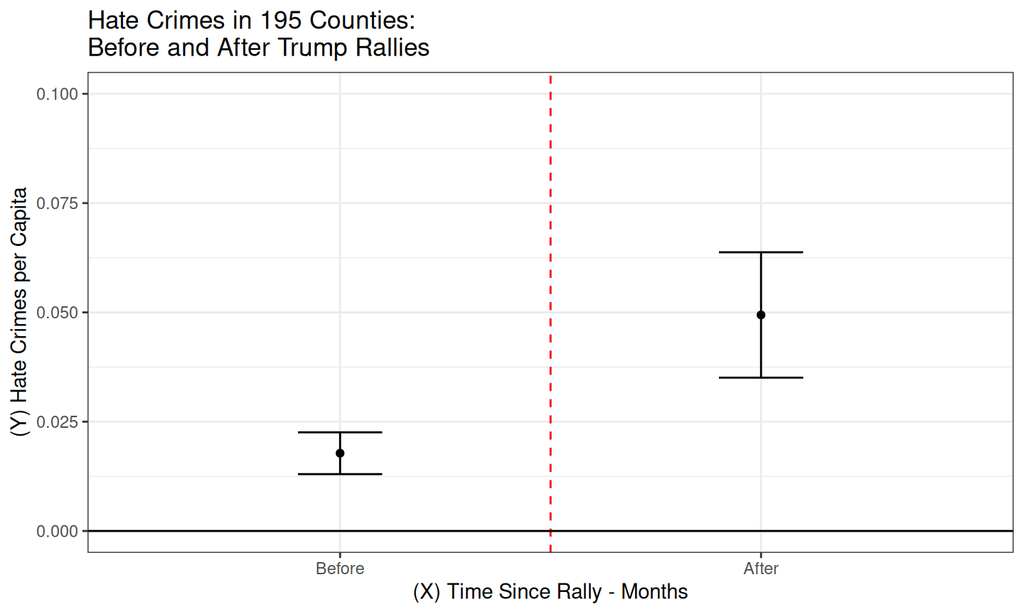

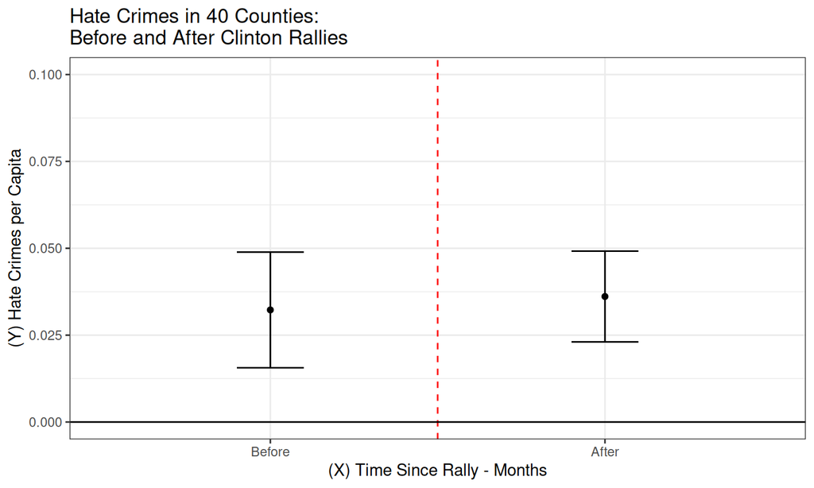

## Before and After

DISCUSS

If we compare counties to themselves **before** and **after** rallies…

1. Which confounding variables are held constant?
2. What are confounding variables that might NOT be addressed in this comparison?

## Design Based Solutions

**Conditioning** removes confounding by:

- **identify** possible confounding variables
- **measure** confounding variables
- relationship b/t \(X\) and \(Y\) for cases with **similar value** of confounding variables \(W\).

## Design Based Solutions

**Design-based** solutions (like **Before and After**) remove confounding by:

- selecting cases for comparison in order to eliminate **many** known/unknown as well as measurable/unmeasurable confounding variables.
- the nature of the comparison holds constant **classes of confounding variables**, not **specific** confounding variables.
- by a “class” we mean all confounding variables that share certain properties

## Example: Before and After

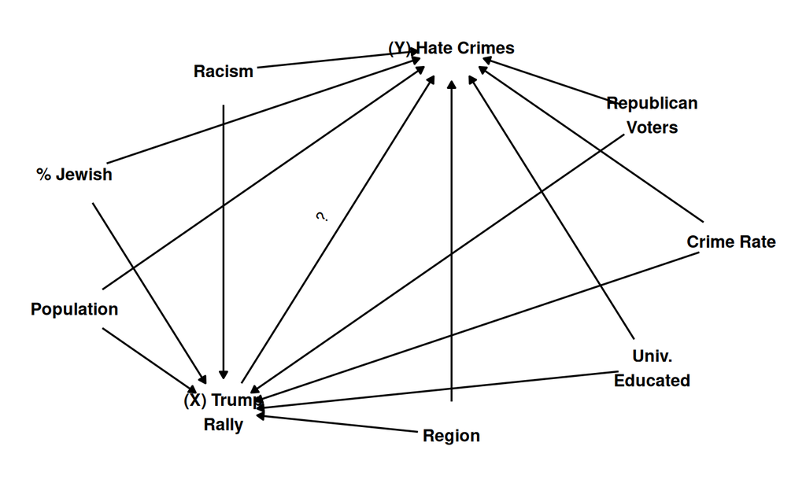

Which of these possible confounders are held constant in a before-and-after comparison?

## Example: Before and After

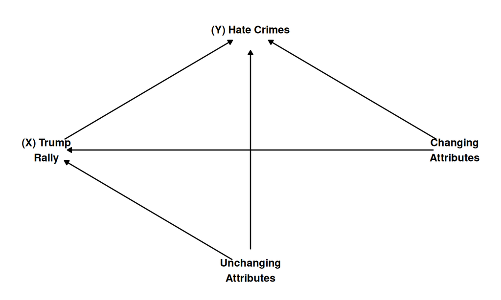

## Example: Before and After

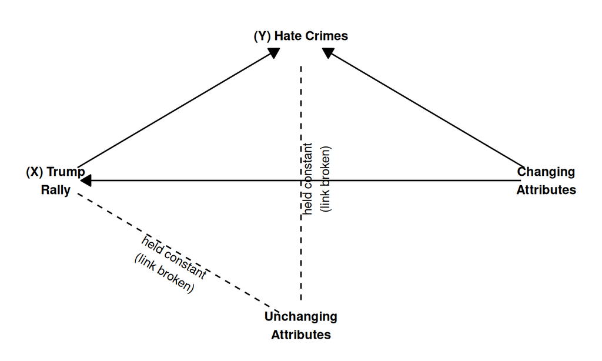

## Example: Before and After

### **How does it work?**…

**All** confounding variables (affect whether a rally occurs; affect hate crimes) that are **unchanging over time** (before to) are held constant.

- because held constant, cannot produce confounding

### **Confounding Solved?**…

- any variable that does not change **in the time period of the comparison** held constant

## Conclusion

## Conclusion

**Conditioning**:

- What is it?:
  - examine correlation of \(X\) and \(Y\) for cases that are the same on confounders \(W\)
- How does it work?:
  - Holds measured confounding variables constant
- Assumptions:
  - no other confounding variables: can’t check
  - no measurement error: can check
  - similar cases with different \(X\): can check
- While imperfect, we should not dismiss this approach.

## Conclusion

**Before and After**:

- What is it?:
  - examine correlation of \(X\) and \(Y\) *within* cases where \(X\) changes over time
- How does it work?:
  - Holds **all unchanging** confounding variables constant
- Assumptions?